# RNA-DESeq2 Report

## Results Tables

Results tables report normalized counts for each gene across replicates within a given contrast, along with the corresponding fold-change values and adjusted p-values from the DESeq2 negative binomial model. Adjusted p-values reflect the statistical significance of differential expression, with lower values indicating stronger evidence against the null hypothesis of equal expression between conditions.

When a gene table is provided, common gene names and/or class annotations are included alongside the original gene identifiers, where available.

### piwi vs wt

| wt_1 | wt_2 | piwi_1 | piwi_2 | Fold_Change | padj |
| --- | --- | --- | --- | --- | --- |
| 82.311 | 83.821 | 9881.274 | 9891.081 | 118.838 | 0 |
| 57.125 | 64.926 | 1994.607 | 2218.972 | 34.268 | 0 |
| 191.153 | 190.148 | 2470.033 | 2422.048 | 12.832 | 0 |
| 407.688 | 468.631 | 3169.836 | 3374.779 | 7.44 | 0 |
| 456.647 | 451.651 | 2975.734 | 3102.033 | 6.694 | 0 |
| 1843.909 | 2197.086 | 150.445 | 129.26 | -14.486 | 0 |
| 1901.646 | 2369.497 | 207.009 | 179.204 | -11.101 | 0 |
| 10538.836 | 9848.246 | 3167.913 | 3147.625 | -3.227 | 0 |
| 24.709 | 30.817 | 1236.263 | 1355.106 | 45.998 | 0 |
| 41.36 | 70.587 | 1238.861 | 1298.703 | 22.114 | 0 |

[output cut: 29960 more lines]

## PCA Plot

The principal component analysis (PCA) plot visualizes the first two principal components derived from the transformed count data for each biological replicate. Samples are colored by experimental condition, allowing patterns of similarity and separation between conditions to be assessed.

Clustering of replicates within the same condition indicates consistency, while separation between conditions reflects differences in overall gene expression profiles.

```
## using ntop=500 top features by variance
```

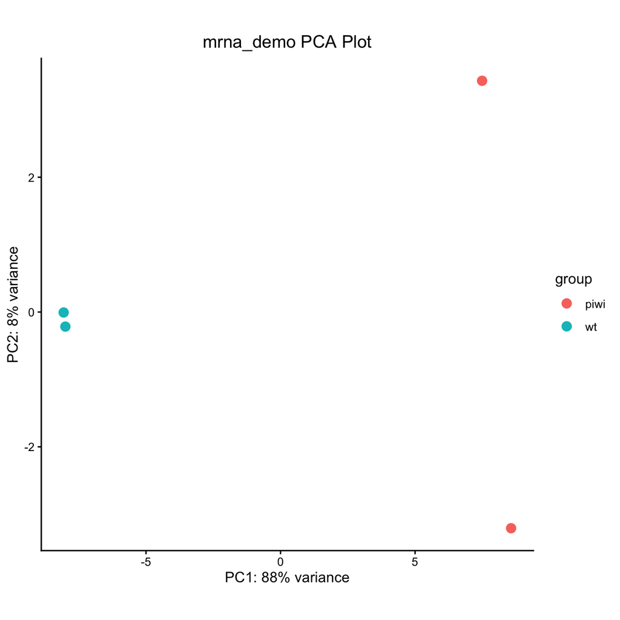

## Intra-Condition Scatterplot

Intra-condition scatter plots compare log₂-transformed normalized counts between pairs of biological replicates within each experimental condition. Counts below one are set to one prior to transformation to avoid undefined log₂ values.

Each plot represents a pairwise comparison of replicates, allowing consistency within conditions to be visually assessed. Points clustering along the diagonal indicate strong agreement between replicates, while increased dispersion may suggest greater variability.

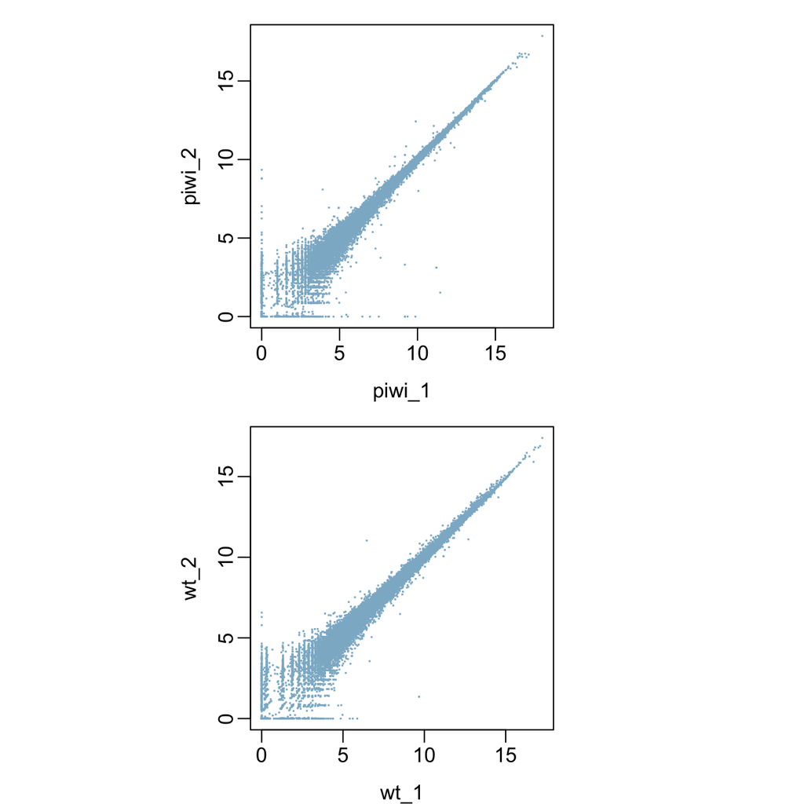

## Mean Reads Scatter Plots

Mean-reads scatter plots display the average log₂ normalized counts across biological replicates for each pair of experimental conditions in a given contrast. Each point represents a gene, allowing overall expression patterns between conditions to be compared.

### Customization

Mean-reads scatter plots can be customized by adjusting the **p-value** and **fold-change** thresholds used to define statistically significant genes. Transparency can also be controlled using **upper and lower thresholds**, where lower transparency is applied to non-significant genes.

When a gene table is provided, points may be **colored and sized** according to gene class. A class-parameters CSV file may be supplied to specify displayed classes and define custom colors and sizes. If no class-parameters file is provided, classes are automatically assigned colors from a default palette, and all points are plotted with a uniform size.

Depending on the selected customization settings, colors may instead reflect statistical significance, or significant genes may retain class-based coloring while non-significant genes are displayed in grey. If no gene table is included, customization is limited to significance thresholds and transparency.

### piwi vs wt

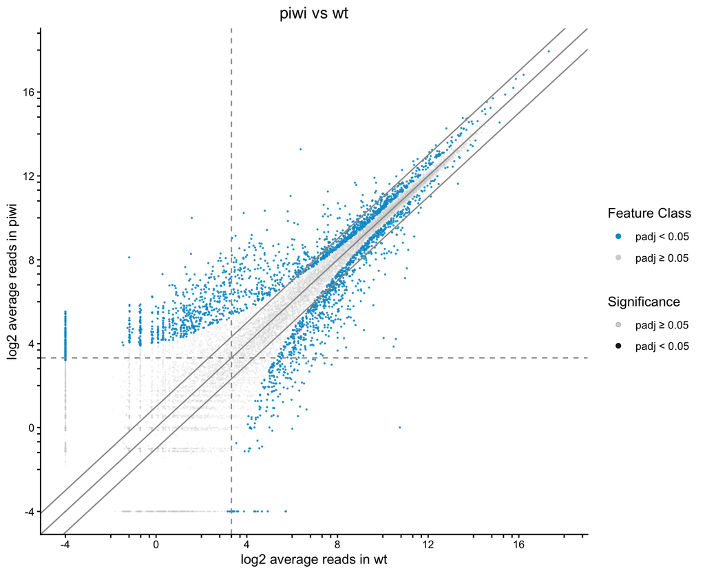

## MA Plots

MA plots, generated using the DESeq2 package, display the log₂ fold change of each gene as a function of its normalized mean count for a given contrast between experimental conditions.

Genes passing the adjusted p-value threshold are highlighted in **blue**, allowing differentially expressed genes to be easily distinguished from the background distribution.

### piwi vs wt

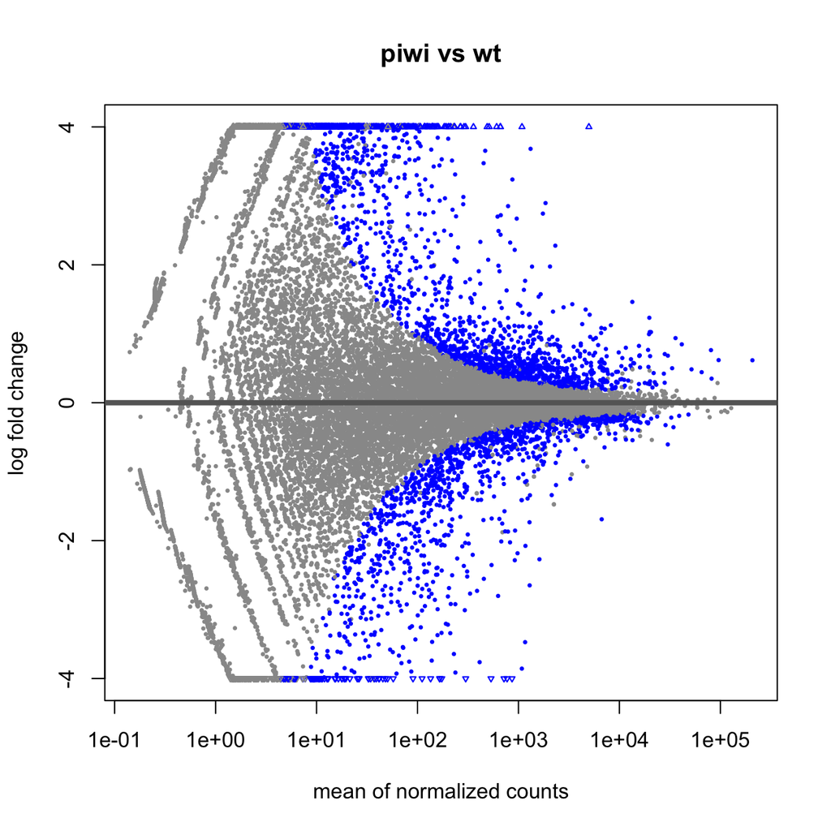

## Heatmap

The **Complete** heatmap displays log₂-transformed normalized counts across all samples for genes with an average log₂ normalized count greater than or equal to 3 (approximately eight normalized counts on average across samples). The plot is rendered using the **heatmaply** package as an interactive HTML widget, allowing zooming, panning, and hover-text exploration. The home button resets the view to its default state. Lower expression values are shown in blue, while higher values are shown in red. Genes are clustered using complete hierarchical clustering with Euclidean distance.

The **Class-Separated: All Classes** heatmap groups genes according to class assignments from the gene table. Genes are organized by class and clustered within each group, with hover text indicating the associated class.

The **Class-Separated: Selected Classes** heatmap generates separate subplots for each class specified in the YAML parameter file. These heatmaps are scaled consistently with the complete heatmap, and subplot dimensions adjust based on the number of genes within each class.

[interactive chart not shown]